# The data verbs: select · filter · mutate · arrange

Tuesday, June 2, 2026

**NoteToday: Tuesday June 2**

**Before class**

- **Perusall Assignment**: [*DC* §10.1–10.6](https://psu.instructure.com/courses/2487468/assignments/18325370)

**Plan for today**

- Four new data verbs: `filter`, `arrange`, `select`, `mutate`
- Sorting verbs by *what they touch*: rows vs. columns
- Combining verbs with the pipe into real pipelines
- Formatting pipelines so they stay readable

**Helpful links**

- Syllabus · AI policy · Schedule · [*R4DS* Ch. 3](https://r4ds.hadley.nz/data-transform) · [*R4DS* Ch. 4](https://r4ds.hadley.nz/workflow-style) · [*DC* Ch. 10](https://dtkaplan.github.io/DataComputingEbook/chap-more-data-verbs.html#chap:more-data-verbs) · [dplyr reference](https://dplyr.tidyverse.org/reference)

## Recap from yesterday

We discussed the overarching **framework** and two data verbs:

| Family | Input to Output | The verb that uses it |
| --- | --- | --- |
| Reduction | variable to scalar | `summarise()` |
| Transformation | variable to variable | *…today: `mutate()`* |
| Data verb | data frame to data frame | all of them |

We write reduction functions inside of `summarise()`. Today we will cover `mutate()`, which contains **transformation** functions, plus three verbs that reshape *which* rows and columns you keep.

## A map of the verbs

We can organize dplyr by **what each verb operates on**:

The dplyr toolkit.

| Touches… | Verbs | What changes |
| --- | --- | --- |
| **Rows** | `filter()`, `arrange()` | which rows, and their order |
| **Columns** | `select()`, `mutate()` | which columns, and new ones |
| **Groups** | `group_by()`, `summarise()` | *(yesterday)* |

**Tip**

These all follow the same three rules: **first argument is a data frame, you name columns without quotes, and the output is a brand-new data frame.**

# Rows: filter()

## filter(): keep the rows you want

`filter()` keeps only the rows that pass a test (*DC* §10.2, R4DS §3.2.1):

```r
penguins |>
  filter(species == "Gentoo")
```

```
# A tibble: 124 × 8
   species island bill_length_mm bill_depth_mm flipper_length_mm body_mass_g
   <fct>   <fct>           <dbl>         <dbl>             <int>       <int>
 1 Gentoo  Biscoe           46.1          13.2               211        4500
 2 Gentoo  Biscoe           50            16.3               230        5700
 3 Gentoo  Biscoe           48.7          14.1               210        4450
 4 Gentoo  Biscoe           50            15.2               218        5700
 5 Gentoo  Biscoe           47.6          14.5               215        5400
 6 Gentoo  Biscoe           46.5          13.5               210        4550
 7 Gentoo  Biscoe           45.4          14.6               211        4800
 8 Gentoo  Biscoe           46.7          15.3               219        5200
 9 Gentoo  Biscoe           43.3          13.4               209        4400
10 Gentoo  Biscoe           46.8          15.4               215        5150
# ℹ 114 more rows
# ℹ 2 more variables: sex <fct>, year <int>
```

The test is a **transformation** that returns `TRUE`/`FALSE` for each row; `filter()` keeps the `TRUE`s.

## The comparison operators

These are the tests you’ll use inside `filter()` (*DC* Table 10.9):

Comparisons for `filter()`.

| Operator | Means | Example |
| --- | --- | --- |
| `==` | equal to | `species == "Gentoo"` |
| `!=` | not equal to | `sex != "male"` |
| `>` `>=` | greater (or equal) | `body_mass_g >= 5000` |
| `<` `<=` | less (or equal) | `flipper_length_mm < 190` |
| `%in%` | is one of | `island %in% c("Dream", "Biscoe")` |

**Warning**

Use `==` to **test** equality, not `=`. A single `=` means “assign,” not “test equality”.

## Multiple conditions

Separate tests with a comma (or `&`) for **AND**, a vertical bar `|` for **OR** (R4DS §3.2.1):

```r
# AND: Adelies that are ALSO on Dream
penguins |>
  filter(species == "Adelie", island == "Dream")

# OR: any penguin that is Adelie OR Gentoo
penguins |>
  filter(species == "Adelie" | species == "Gentoo")

# %in% is the clean way to write a long OR
penguins |>
  filter(species %in% c("Adelie", "Gentoo"))
```

**Note**

`filter(species == "Adelie" | "Gentoo")` does **not** work the way it reads. Each side of `|` must be a complete test.

## Dropping `NA`s

Yesterday, `group_by(species, sex)` gave us an `NA` group because some penguins have a missing `sex`. Now we can drop them:

```r
penguins |>
  filter(!is.na(sex)) |>
  group_by(species, sex) |>
  summarise(n = n(), .groups = "drop")
```

```
# A tibble: 6 × 3
  species   sex        n
  <fct>     <fct>  <int>
1 Adelie    female    73
2 Adelie    male      73
3 Chinstrap female    34
4 Chinstrap male      34
5 Gentoo    female    58
6 Gentoo    male      61
```

`is.na(sex)` is `TRUE` for the missing ones; `!` flips it, so `!is.na(sex)` keeps the rows that **do** have a sex. This removes the `NA` group.

# Rows: arrange()

## arrange(): set the order

`arrange()` reorders rows without adding or removing any. This function gives the result in ascending order by default:

```r
penguins |>
  arrange(body_mass_g)
```

```
# A tibble: 344 × 8
   species   island   bill_length_mm bill_depth_mm flipper_length_mm body_mass_g
   <fct>     <fct>             <dbl>         <dbl>             <int>       <int>
 1 Chinstrap Dream              46.9          16.6               192        2700
 2 Adelie    Biscoe             36.5          16.6               181        2850
 3 Adelie    Biscoe             36.4          17.1               184        2850
 4 Adelie    Biscoe             34.5          18.1               187        2900
 5 Adelie    Dream              33.1          16.1               178        2900
 6 Adelie    Torgers…           38.6          17                 188        2900
 7 Chinstrap Dream              43.2          16.6               187        2900
 8 Adelie    Biscoe             37.9          18.6               193        2925
 9 Adelie    Dream              37.5          18.9               179        2975
10 Adelie    Dream              37            16.9               185        3000
# ℹ 334 more rows
# ℹ 2 more variables: sex <fct>, year <int>
```

You can wrap a column in `desc()` if you want descending order. If there are ties, to break them you can list several columns:

```r
penguins |>
  arrange(species, desc(body_mass_g))   # by species, then heaviest first
```

# Columns: select()

## select(): keep the columns you want

`select()` is to columns what `filter()` is to rows:

```r
penguins |>
  select(species, island, body_mass_g)
```

```
# A tibble: 344 × 3
   species island    body_mass_g
   <fct>   <fct>           <int>
 1 Adelie  Torgersen        3750
 2 Adelie  Torgersen        3800
 3 Adelie  Torgersen        3250
 4 Adelie  Torgersen          NA
 5 Adelie  Torgersen        3450
 6 Adelie  Torgersen        3650
 7 Adelie  Torgersen        3625
 8 Adelie  Torgersen        4675
 9 Adelie  Torgersen        3475
10 Adelie  Torgersen        4250
# ℹ 334 more rows
```

You can grab a range, drop with `!`, or rename as you go:

```r
penguins |> select(species:bill_depth_mm)  # a range of columns
penguins |> select(!year)                  # everything EXCEPT year
penguins |> select(mass = body_mass_g)     # rename while selecting
```

**Note**

`penguins` has only 8 columns, so `select()` feels optional here. On a 19-column table like `flights` from HW2, or a 76-column one, it’s one of the first things you might want to try.

## select() helpers

For wide tables, name columns by pattern instead of one-by-one:

```r
penguins |> select(starts_with("bill"))    # bill_length_mm, bill_depth_mm
penguins |> select(ends_with("_mm"))       # all the millimetre measurements
penguins |> select(where(is.numeric))      # every numeric column
```

# Columns: mutate()

## mutate(): add a new column

`mutate()` adds columns computed from existing ones, keeping every row:

```r
penguins |>
  mutate(body_mass_kg = body_mass_g / 1000) |>
  select(species, body_mass_g, body_mass_kg)
```

```
# A tibble: 344 × 3
   species body_mass_g body_mass_kg
   <fct>         <int>        <dbl>
 1 Adelie         3750         3.75
 2 Adelie         3800         3.8
 3 Adelie         3250         3.25
 4 Adelie           NA        NA
 5 Adelie         3450         3.45
 6 Adelie         3650         3.65
 7 Adelie         3625         3.62
 8 Adelie         4675         4.68
 9 Adelie         3475         3.48
10 Adelie         4250         4.25
# ℹ 334 more rows
```

## mutate() contains transformation functions

> `mutate()` **always** involves a *transformation* function, just as `summarise()` **always** involves a *reduction* function.

```r
# transformation: one value per row to mutate()
penguins |> mutate(bill_ratio = bill_length_mm / bill_depth_mm)

# reduction: one value total to summarise()
penguins |> summarise(avg_bill = mean(bill_length_mm, na.rm = TRUE))
```

**Tip**

Deciding between them is the same question from yesterday: does the calculation give **one value per row** (`mutate`) or **one value for the whole group** (`summarise`)?

## A categorical column with ifelse()

`ifelse()` is a transformation that picks between two values per row, perfect inside `mutate()`:

```r
penguins |>
  mutate(size = ifelse(body_mass_g > 4000, "large", "small")) |>
  select(species, body_mass_g, size)
```

```
# A tibble: 344 × 3
   species body_mass_g size
   <fct>         <int> <chr>
 1 Adelie         3750 small
 2 Adelie         3800 small
 3 Adelie         3250 small
 4 Adelie           NA <NA>
 5 Adelie         3450 small
 6 Adelie         3650 small
 7 Adelie         3625 small
 8 Adelie         4675 large
 9 Adelie         3475 small
10 Adelie         4250 large
# ℹ 334 more rows
```

# Combining verbs

## The pipe does the real work

One verb does one thing. For most questions, we will need several, chained together with `|>`:

```r
penguins |>
  filter(!is.na(sex)) |>
  mutate(body_mass_kg = body_mass_g / 1000) |>
  select(species, sex, body_mass_kg) |>
  arrange(desc(body_mass_kg))
```

This can be read in English as: take penguins, **then** drop missing sex, **then** add mass in kg, **then** keep three columns, **then** sort heaviest first.

**Tip**

Because each verb returns a new data frame, the output of one is the input to the next. The verbs line up on the left so you can quickly skim to understand what’s going on.

```r
penguins |>
  filter(!is.na(sex)) |>
  group_by(species, sex) |>
  summarise(
    n        = n(),
    avg_mass = mean(body_mass_g, na.rm = TRUE),
    .groups  = "drop"
  ) |>
  arrange(desc(avg_mass))
```

```
# A tibble: 6 × 4
  species   sex        n avg_mass
  <fct>     <fct>  <int>    <dbl>
1 Gentoo    male      61    5485.
2 Gentoo    female    58    4680.
3 Adelie    male      73    4043.
4 Chinstrap male      34    3939.
5 Chinstrap female    34    3527.
6 Adelie    female    73    3369.
```

And because the result is just a data frame, you can pipe it straight into a plot (switching `|>` to `+`):

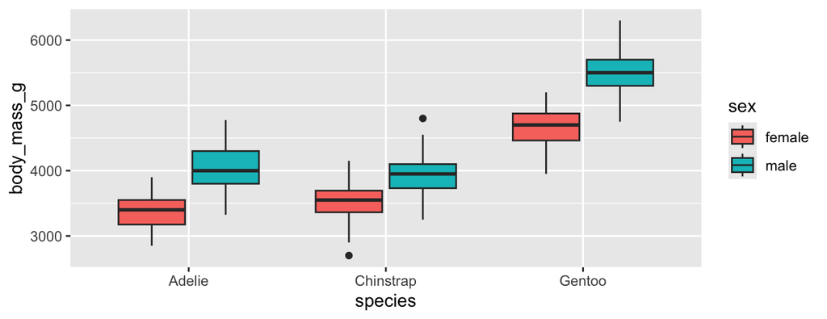

```r
penguins |>
  filter(!is.na(sex)) |>
  ggplot(aes(x = species, y = body_mass_g, fill = sex)) +
  geom_boxplot()
```

## Formatting your pipelines

A multi-step pipeline is only readable if you format it. The rules that matter most:

- A space before `|>`, and let `|>` be the **last thing on the line**.
- For verbs with **named arguments** (`mutate`, `summarise`), put each argument on its **own line**, indented two spaces.
- Verbs without named arguments (`filter`, `select`, `arrange`) can stay on one line if they fit.
- Name new columns in `snake_case`: `body_mass_kg`, not `BodyMassKG`.

```r
# Strive for                          # Avoid
penguins |>                           penguins|>filter(!is.na(sex))|>group_by(
  filter(!is.na(sex)) |>              species)|>summarize(n=n(),avg=mean(
  group_by(species) |>                body_mass_g,na.rm=TRUE))
  summarise(
    n   = n(),
    avg = mean(body_mass_g, na.rm = TRUE)
  )
```

**Tip**

Don’t hand-format forever: the **`styler`** package reformats a whole file for you. In RStudio, `Cmd/Ctrl + Shift + P` then type “styler”. Full guide: R4DS Ch. 4.

## A helpful shortcut

Counting rows per group is so common it has its own verb, `count()`:

```r
penguins |> count(species)

# is exactly the same as
penguins |>
  group_by(species) |>
  summarise(n = n())
```

**Note**

`count()` is just `group_by()` + `summarise(n = n())` bundled up. Add `sort = TRUE` to get the biggest groups first.

## What we covered today

- **`filter()`**: keep rows that pass a test; `==` not `=`; combine with `,`/`|`/`%in%`; `!is.na()` to drop missing
- **`arrange()`**: reorder rows; `desc()` for descending; extra columns break ties
- **`select()`**: keep/drop/rename columns; `starts_with()` & friends for wide tables
- **`mutate()`**: add columns from transformations; the per-row twin of `summarise()`
- **The pipe**: chain verbs into a readable top-to-bottom story; pipe results into ggplot
- **Style**: space before `|>`, named args on their own lines, `snake_case`, let `styler` do the rest

# Activity

## Activity: wrangling the penguins

Roughly 25 minutes. Individually or with a neighbor.

- [Activity Canvas Link](https://psu.instructure.com/courses/2487468/assignments/)

**Format:** a handout that walks each verb, then asks you to chain them. You’ll match tasks to verbs, write `filter`/`arrange`/`select`/`mutate` pipelines on `penguins`, debug a `=` vs `==` error, build one multi-verb pipeline that answers a question, and restyle a deliberately unreadable pipeline.

**To turn in:** save your `.qmd` and rendered HTML.

## Wrap-up & looking ahead

**Tomorrow (Wednesday):** no new reading, we put all six verbs together on a messier dataset and turn raw rows into summary tables and plots.

**Upcoming Deadlines**

- **Thu 6/4, before class**: [*DC* §12.1](https://psu.instructure.com/courses/2487468/assignments/18325371)
- **Thu 6/4, 11:59 p.m.**: [Project: Team formation](https://psu.instructure.com/courses/2487468/assignments/)
- **Fri 6/5, 11:59 p.m.**: [Homework 3: Data Wrangling & Reshaping](https://psu.instructure.com/courses/2487468/assignments/18327019)

**Reach out**

Stuck? Office hours, or email me (cgc5478@psu.edu) or Xinyue (xpw5228@psu.edu).

**Reference**

Syllabus · AI policy · Schedule · [*R4DS* Ch. 3](https://r4ds.hadley.nz/data-transform) · [*R4DS* Ch. 4](https://r4ds.hadley.nz/workflow-style) · [*DC* Ch. 10](https://dtkaplan.github.io/DataComputingEbook/chap-more-data-verbs.html#chap:more-data-verbs) · [dplyr reference](https://dplyr.tidyverse.org/reference)